# Reproducible Research: Peer Assessment 1

## Loading and preprocessing the data

The code used to unzip the original file is included (so it will be fully “reproducible”).

1. Unzip file
2. Read CSV file (with all default parameters)
3. Convert the date to appropriate R format using **as.Date** function

```r
library(lubridate)
```

```r
library(ggplot2)
library(dplyr)
unzip("activity.zip")
ActivityDS=read.csv("activity.csv")
ActivityDS$date=as.Date(ActivityDS$date)
```

## What is mean total number of steps taken per day?

We can use the function **tapply** to calculate the total number of steps (The result is printed per day)

```r
Totals<-tapply(ActivityDS$steps,as.factor(ActivityDS$date),sum,na.rm=TRUE)
Totals
```

```
## 2012-10-01 2012-10-02 2012-10-03 2012-10-04 2012-10-05 2012-10-06 2012-10-07
##          0        126      11352      12116      13294      15420      11015
## 2012-10-08 2012-10-09 2012-10-10 2012-10-11 2012-10-12 2012-10-13 2012-10-14
##          0      12811       9900      10304      17382      12426      15098
## 2012-10-15 2012-10-16 2012-10-17 2012-10-18 2012-10-19 2012-10-20 2012-10-21
##      10139      15084      13452      10056      11829      10395       8821
## 2012-10-22 2012-10-23 2012-10-24 2012-10-25 2012-10-26 2012-10-27 2012-10-28
##      13460       8918       8355       2492       6778      10119      11458
## 2012-10-29 2012-10-30 2012-10-31 2012-11-01 2012-11-02 2012-11-03 2012-11-04
##       5018       9819      15414          0      10600      10571          0
## 2012-11-05 2012-11-06 2012-11-07 2012-11-08 2012-11-09 2012-11-10 2012-11-11
##      10439       8334      12883       3219          0          0      12608
## 2012-11-12 2012-11-13 2012-11-14 2012-11-15 2012-11-16 2012-11-17 2012-11-18
##      10765       7336          0         41       5441      14339      15110
## 2012-11-19 2012-11-20 2012-11-21 2012-11-22 2012-11-23 2012-11-24 2012-11-25
##       8841       4472      12787      20427      21194      14478      11834
## 2012-11-26 2012-11-27 2012-11-28 2012-11-29 2012-11-30
##      11162      13646      10183       7047          0
```

Then we can plot a histogram of the total number of steps taken each day, and calculate mean and median of the total number of steps taken per day:

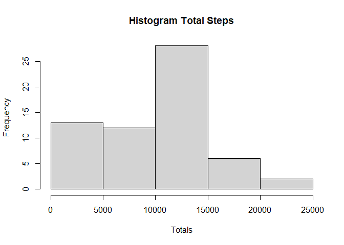

```r
hist(Totals,main="Histogram Total Steps")
```

```r
mean(Totals,na.rm=TRUE)
```

```
## [1] 9354.23
```

```r
median(Totals,na.rm=TRUE)
```

```
## [1] 10395
```

## What is the average daily activity pattern?

We can make a time series plot of the 5-minute interval (x-axis) and the average number of steps taken, averaged across all days (y-axis)

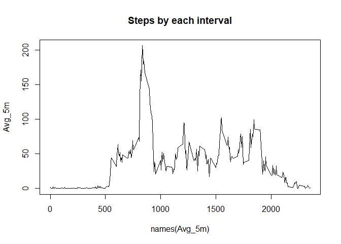

```r
Avg_5m<-tapply(ActivityDS$steps,as.factor(ActivityDS$interval),mean,na.rm=TRUE)
plot(x=names(Avg_5m) , y=Avg_5m,type='l',main="Steps by each interval")
```

```r
Avg_5m[Avg_5m==max(Avg_5m)]
```

```
##      835
## 206.1698
```

```r
as.numeric(names(Avg_5m[Avg_5m==max(Avg_5m)]))/60
```

```
## [1] 13.91667
```

## Imputing missing values

1. Notice there are many missing values in STEPS

```r
sum(is.na(ActivityDS$steps))
```

```
## [1] 2304
```

2. We can choose the following strategy: fill with 0 the missing values (because it make sense that it is 0, maybe the person is inactive,so he/she didn’t move)
3. Creating a new Data Set with 0 in missing values

```r
ActivityDS2=ActivityDS
ActivityDS2$steps[is.na(ActivityDS2$steps)] = 0
```

4. We will repeat the same calculations with 0 in missing values:

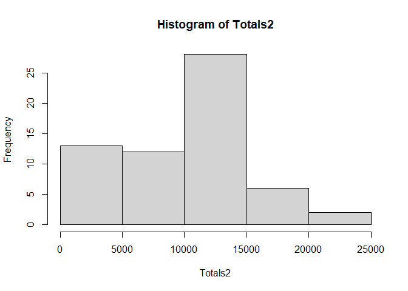

```r
Totals2<-tapply(ActivityDS2$steps,as.factor(ActivityDS2$date),sum,na.rm=FALSE)
hist(Totals2)
```

```r
mean(Totals2,na.rm=TRUE)
```

```
## [1] 9354.23
```

```r
median(Totals2,na.rm=TRUE)
```

```
## [1] 10395
```

Note: The mean and median of the total steps are not different because in the 1st scenario, the NA sums as 0. So with this strategy, the sum of each day is exactly the same.

## Are there differences in activity patterns between weekdays and weekends?

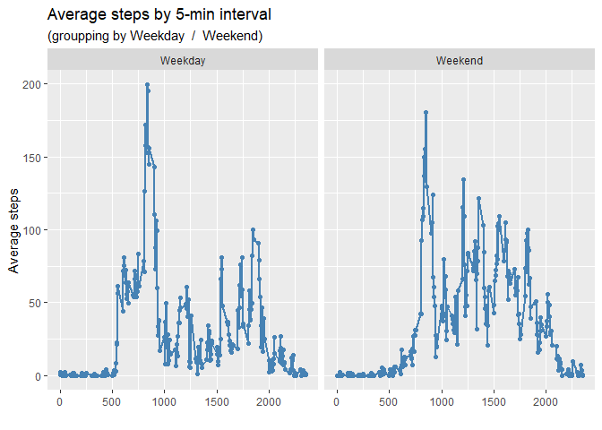

```r
ActivityDS2$dayWeek=wday(ActivityDS2$date,week_start = 1)
ActivityDS2$WeekEndFlag[ActivityDS2$dayWeek>=5]="Weekend"
ActivityDS2$WeekEndFlag[ActivityDS2$dayWeek<5]="Weekday"

Totals3<-aggregate(ActivityDS2$steps, list(ActivityDS2$interval,
                                           ActivityDS2$WeekEndFlag), mean)

names(Totals3)=c("interval","WeekFlag","Steps")

ggplot(data = Totals3, aes(interval, Steps)) +
  geom_line(color = "steelblue", size = 1) +
  geom_point(color="steelblue") +
  labs(title = "Average steps by 5-min interval",
       subtitle = "(groupping by Weekday  /  Weekend)",
       y = "Average steps", x = "") +
  facet_wrap(~ WeekFlag)
```